# Classification Model for Breast Cancer Wisconsin (Original) Data Set with Ensemble

David Lowe

January 28, 2018

# R Project Template

Template Credit: Adapted from template made available by Dr. Jason Brownlee of Machine Learning Mastery (http://machinelearningmastery.com/)

Data Set Description: https://archive.ics.uci.edu/ml/datasets/Breast+Cancer+Wisconsin+(Original) Benchmark References: https://www.kaggle.com/uciml/breast-cancer-wisconsin-data Modeling Approach: binary classification, converting categorical to numerical attributes

Working through machine learning problems from end-to-end requires a structured modeling approach. Working problems through a project template can encourage you to think about the problem more critically, to challenge your assumptions, and to get good at all parts of a modeling project.

Any predictive modeling machine learning project can be broken down into about 6 common tasks:

1. Define Problem
2. Summarize Data
3. Prepare Data
4. Evaluate Algorithms
5. Improve Accuracy or Results
6. Finalize Model and Present Results

We will compare several different algorithms and determine which one would yield the best results.

## 1. Prepare Problem

### 1.a) Load libraries

```r
library(mlbench)
library(caret)
```

### 1.b) Load dataset

```r
data(BreastCancer)
```

### 1.c) Split-out validation dataset

Create a training (variable name “dataset”) and a validation (variable name “validation”) dataset

```r
seed_num <- 7
# Split out validation dataset
# create a list of 80% of the rows in the original dataset we can use for training
set.seed(seed_num)
training_index <- createDataPartition(BreastCancer$Class, p=0.80, list=FALSE)
# select 20% of the data for validation
validation <- BreastCancer[-training_index,]
# use the remaining 80% of data to training and testing the models
dataset <- BreastCancer[training_index,]
```

```r
# Remove redundant variable Id
dataset <- dataset[,-1]
validation <- validation[,-1]
# convert input values to numeric
for(i in 1:9) {
    dataset[,i] <- as.numeric(as.character(dataset[,i]))
    validation[,i] <- as.numeric(as.character(validation[,i]))
}
```

## 2. Summarize Data

To gain a better understanding of the data that we have on-hand, we will leverage a number of descriptive statistics and data visualization techniques. The plan is to use the results to consider new questions, review assumptions, and validate hypotheses that we can investigate later with specialized models.

### 2.a) Descriptive statistics

#### 2.a.i) Dimensions of the dataset.

```r
dim(dataset)
```

```
## [1] 560  10
```

#### 2.a.ii) Types of the attributes.

```r
sapply(dataset, class)
```

```
##    Cl.thickness       Cell.size      Cell.shape   Marg.adhesion
##       "numeric"       "numeric"       "numeric"       "numeric"
##    Epith.c.size     Bare.nuclei     Bl.cromatin Normal.nucleoli
##       "numeric"       "numeric"       "numeric"       "numeric"
##         Mitoses           Class
##       "numeric"        "factor"
```

#### 2.a.iii) Peek at the data itself.

```r
head(dataset, n=20)
```

```
##    Cl.thickness Cell.size Cell.shape Marg.adhesion Epith.c.size
## 2             5         4          4             5            7
## 4             6         8          8             1            3
## 5             4         1          1             3            2
## 6             8        10         10             8            7
## 7             1         1          1             1            2
## 9             2         1          1             1            2
## 10            4         2          1             1            2
## 11            1         1          1             1            1
## 12            2         1          1             1            2
## 14            1         1          1             1            2
## 15            8         7          5            10            7
## 16            7         4          6             4            6
## 17            4         1          1             1            2
## 18            4         1          1             1            2
```

[output cut: 27 more lines]

#### 2.a.iv) Levels of the class attribute.

#### 2.a.v) Breakdown of the instances in each class.

#### 2.a.vi) Statistical summary of all attributes.

```r
summary(dataset)
```

```
##   Cl.thickness      Cell.size        Cell.shape     Marg.adhesion
##  Min.   : 1.000   Min.   : 1.000   Min.   : 1.000   Min.   : 1.000
##  1st Qu.: 2.000   1st Qu.: 1.000   1st Qu.: 1.000   1st Qu.: 1.000
##  Median : 4.000   Median : 1.000   Median : 2.000   Median : 1.000
##  Mean   : 4.384   Mean   : 3.116   Mean   : 3.198   Mean   : 2.875
##  3rd Qu.: 6.000   3rd Qu.: 5.000   3rd Qu.: 5.000   3rd Qu.: 4.000
##  Max.   :10.000   Max.   :10.000   Max.   :10.000   Max.   :10.000
##
##   Epith.c.size     Bare.nuclei      Bl.cromatin     Normal.nucleoli
##  Min.   : 1.000   Min.   : 1.000   Min.   : 1.000   Min.   : 1.000
##  1st Qu.: 2.000   1st Qu.: 1.000   1st Qu.: 2.000   1st Qu.: 1.000
##  Median : 2.000   Median : 1.000   Median : 3.000   Median : 1.000
##  Mean   : 3.232   Mean   : 3.468   Mean   : 3.405   Mean   : 2.877
##  3rd Qu.: 4.000   3rd Qu.: 5.000   3rd Qu.: 4.250   3rd Qu.: 4.000
##  Max.   :10.000   Max.   :10.000   Max.   :10.000   Max.   :10.000
##                   NA's   :13
##     Mitoses             Class
##  Min.   : 1.000   benign   :367
##  1st Qu.: 1.000   malignant:193
##  Median : 1.000
##  Mean   : 1.611
##  3rd Qu.: 1.000
##  Max.   :10.000
##
```

### 2.b) Data visualizations

#### 2.b.i) Univariate plots to better understand each attribute.

#### 2.b.ii) Multivariate plots to better understand the relationships between attributes

```r
# class distribution
cbind(freq=table(dataset$Class), percentage=prop.table(table(dataset$Class))*100)
```

```
##           freq percentage
## benign     367   65.53571
## malignant  193   34.46429
```

```r
# summarize correlations between input variables
complete_cases <- complete.cases(dataset)
cor(dataset[complete_cases,1:9])
```

```
##                 Cl.thickness Cell.size Cell.shape Marg.adhesion
## Cl.thickness       1.0000000 0.6200884  0.6302917     0.4741733
## Cell.size          0.6200884 1.0000000  0.9011340     0.7141150
## Cell.shape         0.6302917 0.9011340  1.0000000     0.6846206
## Marg.adhesion      0.4741733 0.7141150  0.6846206     1.0000000
## Epith.c.size       0.5089557 0.7404824  0.7043423     0.5860660
## Bare.nuclei        0.5600770 0.6687226  0.6896724     0.6660165
## Bl.cromatin        0.5290733 0.7502700  0.7276114     0.6660533
## Normal.nucleoli    0.5143933 0.7072182  0.7127155     0.6031036
## Mitoses            0.3426018 0.4506532  0.4345125     0.4314910
##                 Epith.c.size Bare.nuclei Bl.cromatin Normal.nucleoli
## Cl.thickness       0.5089557   0.5600770   0.5290733       0.5143933
## Cell.size          0.7404824   0.6687226   0.7502700       0.7072182
## Cell.shape         0.7043423   0.6896724   0.7276114       0.7127155
## Marg.adhesion      0.5860660   0.6660165   0.6660533       0.6031036
## Epith.c.size       1.0000000   0.5568406   0.6102032       0.6433364
## Bare.nuclei        0.5568406   1.0000000   0.6668483       0.5795794
## Bl.cromatin        0.6102032   0.6668483   1.0000000       0.6838547
## Normal.nucleoli    0.6433364   0.5795794   0.6838547       1.0000000
## Mitoses            0.4775271   0.3539473   0.3545122       0.4084127
##                   Mitoses
## Cl.thickness    0.3426018
## Cell.size       0.4506532
## Cell.shape      0.4345125
## Marg.adhesion   0.4314910
## Epith.c.size    0.4775271
## Bare.nuclei     0.3539473
## Bl.cromatin     0.3545122
## Normal.nucleoli 0.4084127
## Mitoses         1.0000000
```

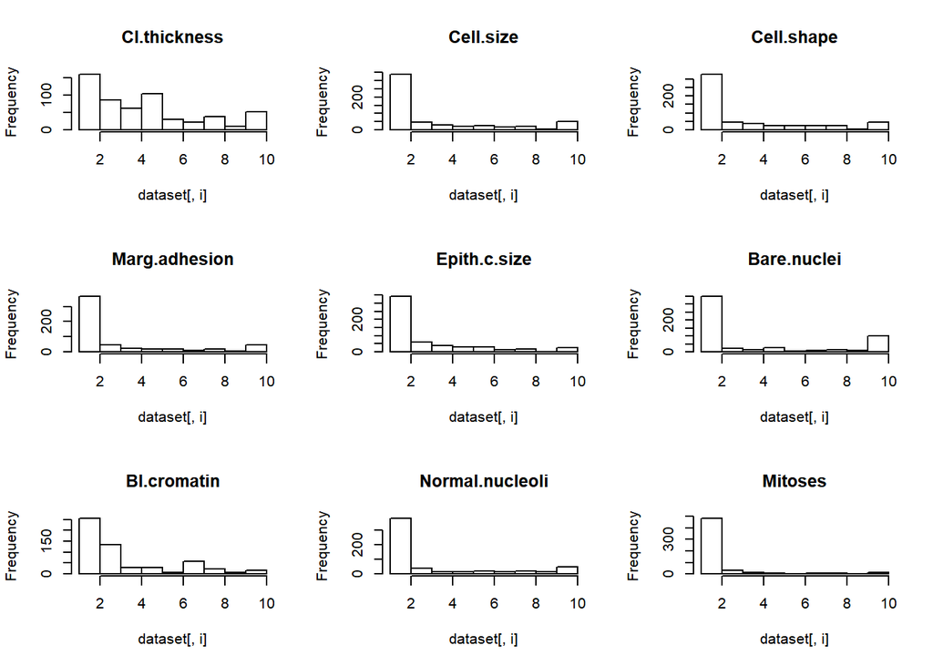

```r
# histograms each attribute
par(mfrow=c(3,3))
for(i in 1:9) {
    hist(dataset[,i], main=names(dataset)[i])
}
```

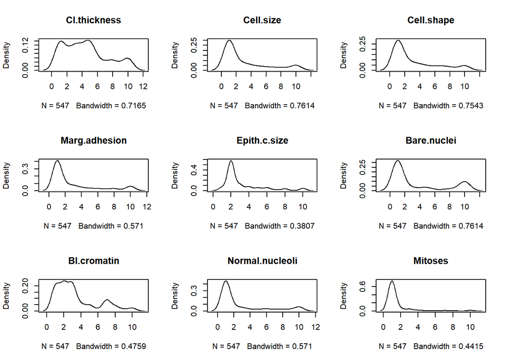

```r
# density plot for each attribute
par(mfrow=c(3,3))
complete_cases <- complete.cases(dataset)
for(i in 1:9) {
    plot(density(dataset[complete_cases,i]), main=names(dataset)[i])
}
```

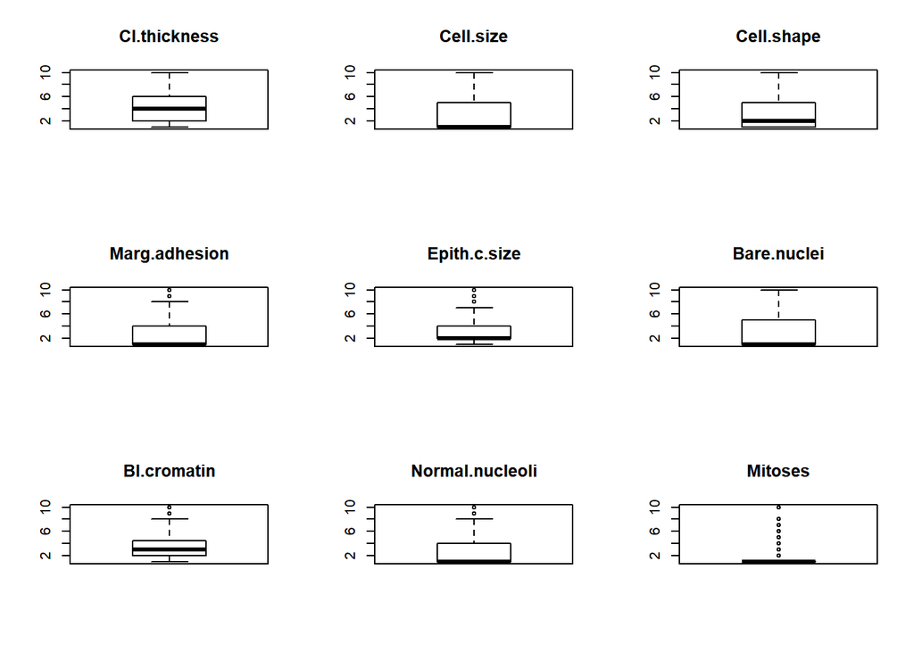

```r
# boxplots for each attribute
par(mfrow=c(3,3))
for(i in 1:9) {
    boxplot(dataset[,i], main=names(dataset)[i])
}
```

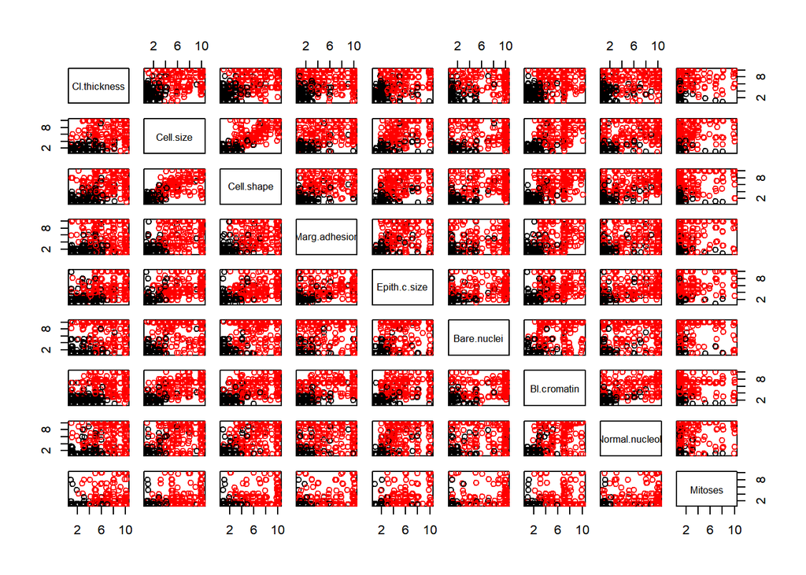

```r
# scatterplot matrix
jittered_x <- sapply(dataset[,1:9], jitter)
pairs(jittered_x, names(dataset[,1:9]), col=dataset$Class)
```

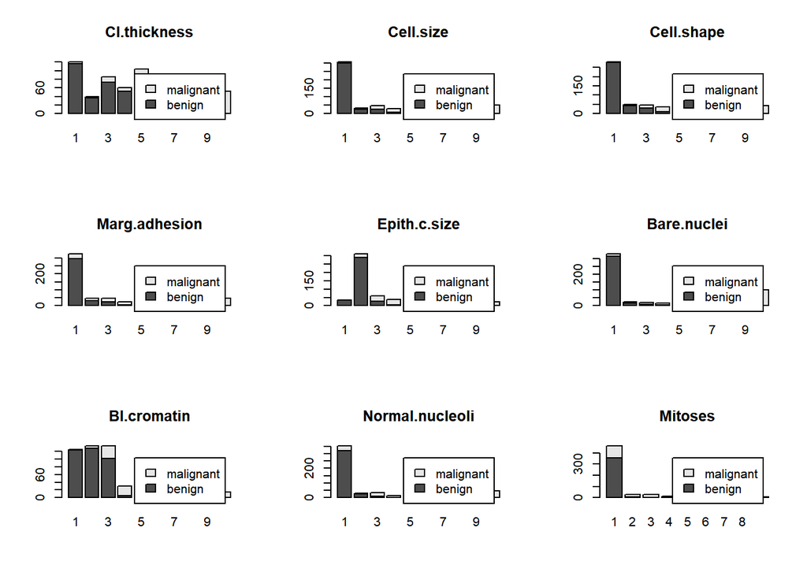

```r
# bar plots of each variable by class
par(mfrow=c(3,3))
for(i in 1:9) {
    barplot(table(dataset$Class,dataset[,i]), main=names(dataset)[i], legend.text=unique(dataset$Class))
}
```

## 3. Prepare Data

Some dataset may require additional preparation activities that will best exposes the structure of the problem and the relationships between the input attributes and the output variable. Some data-prep tasks might include:

- Cleaning data by removing duplicates, marking missing values and even imputing missing values.
- Feature selection where redundant features may be removed.
- Data transforms where attributes are scaled or redistributed in order to best expose the structure of the problem later to learning algorithms.

### 3.a) Data Cleaning

### 3.b) Feature Selection

### 3.c) Data Transforms

## 4. Evaluate Algorithms - No Transformation

After the data-prep, we next work on finding a workable model by evaluating a subset of machine learning algorithms that are good at exploiting the structure of the dataset. The typical evaluation tasks include:

- Defining test options such as cross validation and the evaluation metric to use.
- Spot checking a suite of linear and nonlinear machine learning algorithms.
- Comparing the estimated accuracy of algorithms.

### 4.a) Test options and evaluation metric

```r
# 10-fold cross validation with 3 repeats
control <- trainControl(method="repeatedcv", number=10, repeats=3)
metric <- "Accuracy"
```

### 4.b) Generate Models using Algorithms

```r
# No Transformation on the dataset
# LG
set.seed(seed_num)
fit.glm <- train(Class~., data=dataset, method="glm", metric=metric, trControl=control, na.action=na.omit)
# LDA
set.seed(seed_num)
fit.lda <- train(Class~., data=dataset, method="lda", metric=metric, trControl=control, na.action=na.omit)
# GLMNET
set.seed(seed_num)
fit.glmnet <- train(Class~., data=dataset, method="glmnet", metric=metric, trControl=control, na.action=na.omit)
# KNN
set.seed(seed_num)
fit.knn <- train(Class~., data=dataset, method="knn", metric=metric, trControl=control, na.action=na.omit)
# CART
set.seed(seed_num)
fit.cart <- train(Class~., data=dataset, method="rpart", metric=metric, trControl=control, na.action=na.omit)
# SVM
set.seed(seed_num)
fit.svm <- train(Class~., data=dataset, method="svmRadial", metric=metric, trControl=control, na.action=na.omit)
```

```r
# BoxCox Transformation on the dataset
# LG
set.seed(seed_num)
fit.glm.bx <- train(Class~., data=dataset, method="glm", metric=metric, preProc=c("BoxCox"), trControl=control, na.action=na.omit)
# LDA
set.seed(seed_num)
fit.lda.bx <- train(Class~., data=dataset, method="lda", metric=metric, preProc=c("BoxCox"), trControl=control, na.action=na.omit)
# GLMNET
set.seed(seed_num)
fit.glmnet.bx <- train(Class~., data=dataset, method="glmnet", metric=metric, preProc=c("BoxCox"), trControl=control, na.action=na.omit)
# KNN
set.seed(seed_num)
fit.knn.bx <- train(Class~., data=dataset, method="knn", metric=metric, preProc=c("BoxCox"), trControl=control, na.action=na.omit)
# CART
set.seed(seed_num)
fit.cart.bx <- train(Class~., data=dataset, method="rpart", metric=metric, preProc=c("BoxCox"), trControl=control, na.action=na.omit)
# SVM
set.seed(seed_num)
fit.svm.bx <- train(Class~., data=dataset, method="svmRadial", metric=metric, preProc=c("BoxCox"), trControl=control, na.action=na.omit)
```

### 4.c) Compare Algorithms

We used the same dataset but with a slight twist in transformation and compared the results. The dataset transformed with BoxCox approach appreaed to get better results from the algorithms. For example, the best-performing algorithm, KNN, did better when applying the BoxCox transformation to pre-process the dataset.

```r
# No Transformation on the dataset
results <- resamples(list(LG=fit.glm, LDA=fit.lda, GLMNET=fit.glmnet, KNN=fit.knn, CART=fit.cart, SVM=fit.svm))
summary(results)
```

```
##
## Call:
## summary.resamples(object = results)
##
## Models: LG, LDA, GLMNET, KNN, CART, SVM
## Number of resamples: 30
##
## Accuracy
##             Min.   1st Qu.    Median      Mean   3rd Qu. Max. NA's
## LG     0.8909091 0.9498316 0.9636364 0.9609977 0.9814815    1    0
## LDA    0.8888889 0.9454545 0.9629630 0.9585734 0.9771825    1    0
## GLMNET 0.8909091 0.9498316 0.9636364 0.9640392 0.9818182    1    0
## KNN    0.9090909 0.9629630 0.9728836 0.9707620 0.9818182    1    0
## CART   0.8571429 0.9090909 0.9272727 0.9324311 0.9461851    1    0
## SVM    0.8909091 0.9444444 0.9629630 0.9518951 0.9641234    1    0
##
## Kappa
##             Min.   1st Qu.    Median      Mean   3rd Qu. Max. NA's
## LG     0.7526237 0.8903491 0.9200813 0.9136612 0.9591931    1    0
## LDA    0.7440758 0.8778682 0.9187970 0.9073541 0.9493543    1    0
## GLMNET 0.7526237 0.8903491 0.9207048 0.9203519 0.9601869    1    0
## KNN    0.8014440 0.9195906 0.9402224 0.9355909 0.9598811    1    0
## CART   0.7083333 0.8011046 0.8464753 0.8531748 0.8859322    1    0
## SVM    0.7755102 0.8799491 0.9207048 0.8972223 0.9220518    1    0
```

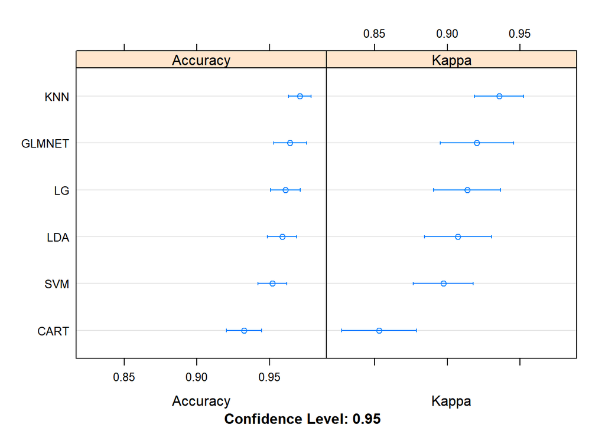

```r
dotplot(results)
```

```r
# No Transformation on the dataset
results <- resamples(list(LG=fit.glm.bx, LDA=fit.lda.bx, GLMNET=fit.glmnet.bx, KNN=fit.knn.bx, CART=fit.cart.bx, SVM=fit.svm.bx))
summary(results)
```

```
##
## Call:
## summary.resamples(object = results)
##
## Models: LG, LDA, GLMNET, KNN, CART, SVM
## Number of resamples: 30
##
## Accuracy
##             Min.   1st Qu.    Median      Mean   3rd Qu. Max. NA's
## LG     0.8727273 0.9454545 0.9725589 0.9640063 0.9818182    1    0
## LDA    0.8909091 0.9629630 0.9725589 0.9683045 0.9818182    1    0
## GLMNET 0.9259259 0.9629630 0.9636364 0.9694833 0.9818182    1    0
## KNN    0.8727273 0.9631313 0.9814815 0.9719633 0.9818182    1    0
## CART   0.8571429 0.9090909 0.9272727 0.9324311 0.9461851    1    0
## SVM    0.9090909 0.9631313 0.9636364 0.9719525 0.9818182    1    0
##
## Kappa
##             Min.   1st Qu.    Median      Mean   3rd Qu. Max. NA's
## LG     0.7286822 0.8808664 0.9402224 0.9208886 0.9602888    1    0
## LDA    0.7701950 0.9195906 0.9407109 0.9313355 0.9602888    1    0
## GLMNET 0.8335901 0.9198692 0.9215407 0.9335337 0.9602888    1    0
## KNN    0.7286822 0.9207048 0.9598811 0.9391947 0.9602888    1    0
## CART   0.7083333 0.8011046 0.8464753 0.8531748 0.8859322    1    0
## SVM    0.8107364 0.9207048 0.9215407 0.9396187 0.9602888    1    0
```

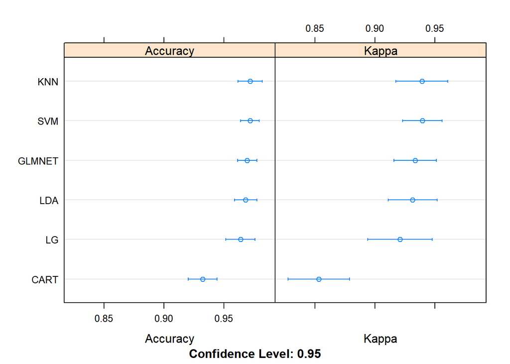

```r
dotplot(results)
```

## 5. Improve Accuracy

After we achieve a short list of machine learning algorithms with good level of accuracy, we can leverage ways to improve the accuracy of the models:

- Search for a combination of parameters for each algorithm using caret that yields the best results.
- Combine the prediction of multiple models into an ensemble prediction using standalone algorithms or the caretEnsemble package.

### 5.a) Algorithm Tuning

```r
# Tuning kNN with BoxCox Transformation
set.seed(seed_num)
grid <- expand.grid(.k=seq(1,20,by=1))
fit.knn <- train(Class~., data=dataset, method="knn", metric=metric, tuneGrid=grid, preProc=c("BoxCox"), trControl=control, na.action=na.omit)
print(fit.knn)
```

```
## k-Nearest Neighbors
##
## 560 samples
##   9 predictor
##   2 classes: 'benign', 'malignant'
##
## Pre-processing: Box-Cox transformation (9)
## Resampling: Cross-Validated (10 fold, repeated 3 times)
## Summary of sample sizes: 492, 493, 492, 492, 493, 491, ...
## Resampling results across tuning parameters:
##
##   k   Accuracy   Kappa
##    1  0.9500325  0.8894817
##    2  0.9531069  0.8967630
##    3  0.9628495  0.9188475
##    4  0.9603363  0.9128179
##    5  0.9688997  0.9323375
##    6  0.9695166  0.9339598
##    7  0.9719633  0.9391947
##    8  0.9719525  0.9391787
##    9  0.9713572  0.9378967
##   10  0.9701451  0.9351851
##   11  0.9713244  0.9378279
##   12  0.9713464  0.9378517
##   13  0.9719525  0.9392355
##   14  0.9725585  0.9405913
##   15  0.9719525  0.9392355
##   16  0.9713464  0.9378517
##   17  0.9725585  0.9405913
##   18  0.9719412  0.9392854
##   19  0.9713352  0.9379938
##   20  0.9713352  0.9379938
##
## Accuracy was used to select the optimal model using the largest value.
## The final value used for the model was k = 17.
```

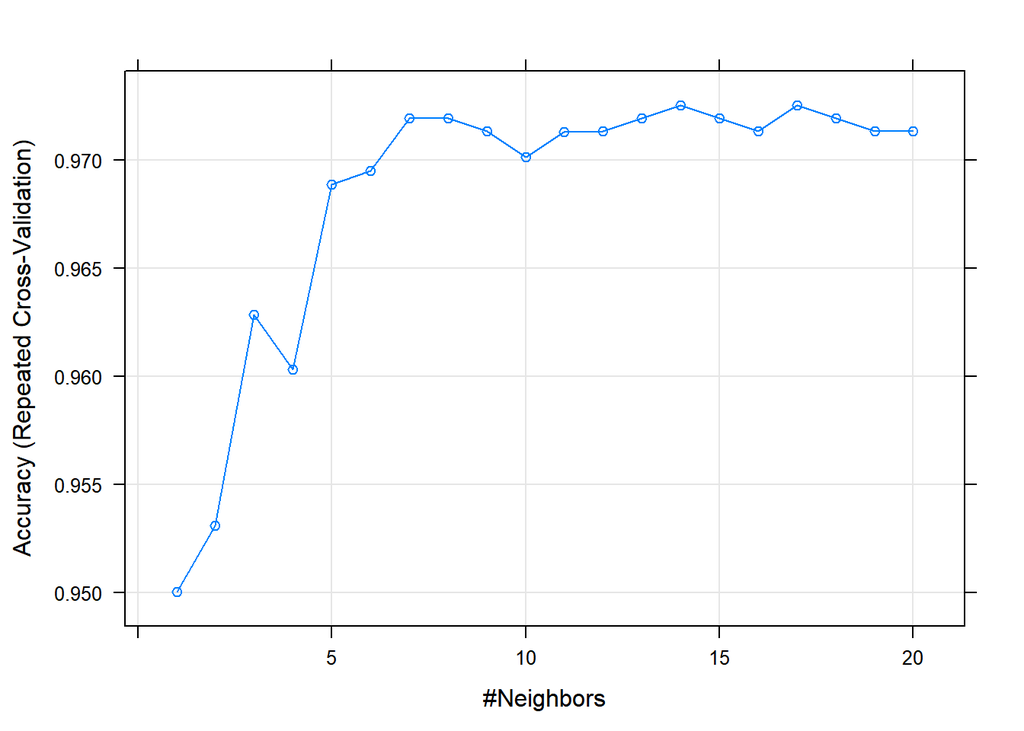

```r
plot(fit.knn)
```

### 5.b) Ensembles

At the same time, we will also look at the ensemble methods to see whether we can optimize the predictive model further. The Random Forest appeared to yield the best accuracy out of the three emsemble models.

```r
# 10-fold cross validation with 3 repeats
control <- trainControl(method="repeatedcv", number=10, repeats=3)
metric <- "Accuracy"
# Bagged CART
set.seed(seed_num)
fit.treebag <- train(Class~., data=dataset, method="treebag", metric=metric, trControl=control, na.action=na.omit)
# Random Forest
set.seed(seed_num)
fit.rf <- train(Class~., data=dataset, method="rf", metric=metric, preProc=c("BoxCox"), trControl=control, na.action=na.omit)
# Stochastic Gradient Boosting
set.seed(seed_num)
fit.gbm <- train(Class~., data=dataset, method="gbm", metric=metric, preProc=c("BoxCox"), trControl=control, verbose=FALSE, na.action=na.omit)
# Compare results
ensemble_results <- resamples(list(BAG=fit.treebag, RF=fit.rf, GBM=fit.gbm))
summary(ensemble_results)
```

```
##
## Call:
## summary.resamples(object = ensemble_results)
##
## Models: BAG, RF, GBM
## Number of resamples: 30
##
## Accuracy
##          Min.   1st Qu.    Median      Mean   3rd Qu. Max. NA's
## BAG 0.8727273 0.9454545 0.9632997 0.9622439 0.9818182    1    0
## RF  0.9272727 0.9629630 0.9816498 0.9731309 0.9818182    1    0
## GBM 0.8727273 0.9498316 0.9636364 0.9622439 0.9818182    1    0
##
## Kappa
##          Min.   1st Qu.    Median      Mean   3rd Qu. Max. NA's
## BAG 0.7286822 0.8808664 0.9207048 0.9173235 0.9597332    1    0
## RF  0.8391813 0.9207048 0.9595853 0.9415904 0.9602888    1    0
## GBM 0.7076689 0.8900351 0.9207048 0.9162823 0.9601869    1    0
```

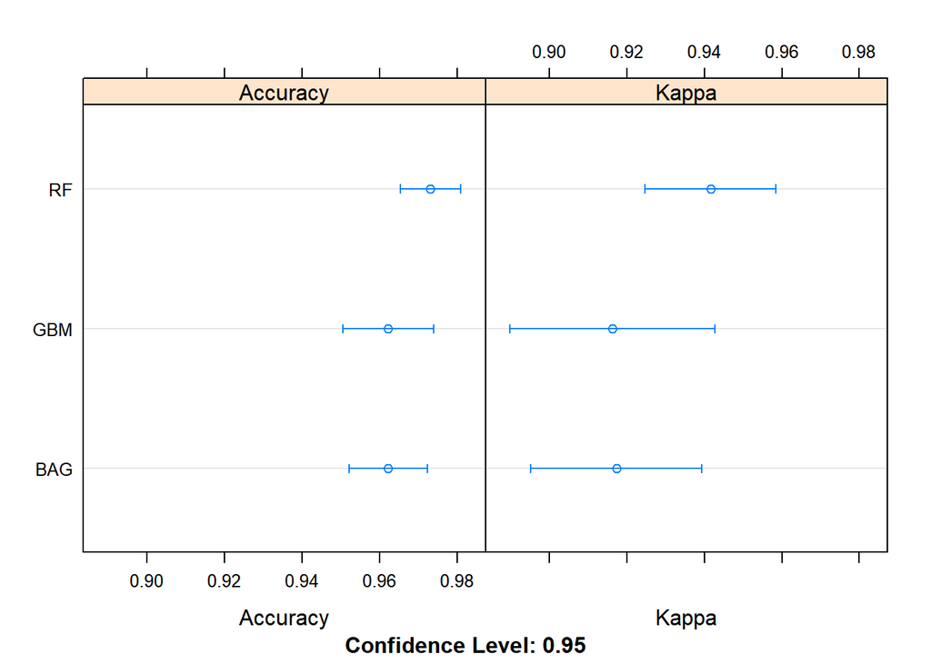

```r
dotplot(ensemble_results)
```

## 6. Finalize Model

Once we have narrow down to a model that we believe can make accurate predictions on unseen data, we are ready to finalize it. Finalizing a model may involve sub-tasks such as:

- Using an optimal model tuned to make predictions on unseen data.
- Creating a standalone model using the tuned parameters
- Saving an optimal model to file for later use.

For this particular dataset, we will settle on using the KNN algorithm with a K value of 17.

### 6.a) Predictions on validation dataset

```r
# prepare parameters for data transform
set.seed(seed_num)
# remove missing values (not allowed in this implementation of knn)
dataset_nomissing <- dataset[complete.cases(dataset),]
x <- dataset_nomissing[,1:9]
preprocessParams <- preProcess(x, method=c("BoxCox"))
x <- predict(preprocessParams, x)

# prepare the validation dataset
# remove missing values (not allowed in this implementation of knn)
validation <- validation[complete.cases(validation),]
# transform the validation dataset
validation_x <- predict(preprocessParams, validation[,1:9])

# make predictions
predictions <- knn3Train(x, validation_x, dataset_nomissing$Class, k=17, prob=FALSE)
confusionMatrix(predictions, validation$Class)
```

```
## Confusion Matrix and Statistics
##
##            Reference
## Prediction  benign malignant
##   benign        87         0
##   malignant      1        48
##
##                Accuracy : 0.9926
##                  95% CI : (0.9597, 0.9998)
##     No Information Rate : 0.6471
##     P-Value [Acc > NIR] : <2e-16
##
##                   Kappa : 0.984
##  Mcnemar's Test P-Value : 1
##
##             Sensitivity : 0.9886
##             Specificity : 1.0000
##          Pos Pred Value : 1.0000
##          Neg Pred Value : 0.9796
##              Prevalence : 0.6471
##          Detection Rate : 0.6397
##    Detection Prevalence : 0.6397
##       Balanced Accuracy : 0.9943
##
##        'Positive' Class : benign
##
```

### 6.b) Create standalone model on entire training dataset

### 6.c) Save model for later use